# Métodos de Machine Learning na Produtividade de Soja

Arthur Hintz, Lucas Sartor

25 nov 2025

# Resumo

O trabalho tem como objetivo realizar uma análise de regressão linear múltipla para estimar a produtividade de soja em (Kg/ha) com base nos principais fatores que a influenciam. A análise será dividida em quatro etapas principais: análise descritiva, ajuste do modelo, diagnóstico de influência e teste das suposições do modelo.

# Introdução

Segundo a Confederação da Agricultura e Pecuária do Brasil (CNA), o Produto Interno Bruto (PIB) do Agronegócio corresponde a 23,8% em 2023, sendo a soja a commodity de maior valor de produção no Brasil, de acordo com dados divulgados pelo IBGE, [link de acesso](https://www.ibge.gov.br/explica/producao-agropecuaria/). Na produção de soja, muitos fatores influenciam o resultado, sendo vários deles incontroláveis, como fatores climáticos. Este ano, por exemplo, houve um aumento de 70,83% na produtividade em relação ao ano anterior, provavelmente relacionado ao volume de precipitação.

Dessa forma, torna-se necessário estimar a produtividade da soja e verificar quais são as principais variáveis que a influenciam, permitindo realizar predições da safra e estimar o potencial de produção a nível nacional.

Inicialmente, será realizada uma análise descritiva dos dados para compreender as variáveis envolvidas e suas inter-relações. Em seguida, o modelo de regressão linear múltipla será ajustado para identificar os fatores mais significativos que afetam a produtividade da soja. O diagnóstico de influência ajudará a identificar pontos de dados que têm um impacto desproporcional no ajuste do modelo, possibilitando a correção ou análise adicional desses pontos. Finalmente, as suposições do modelo de regressão linear serão testadas para garantir a validade das conclusões obtidas.

Os dados utilizados neste estudo foram disponibilizados pela empresa Crops Team e foram coletados a partir de experimentos com cultivares de soja realizados em diversos locais do estado do Rio Grande do Sul durante as safras de 2021/2022 e 2022/2023.

Este estudo é importante porque permite identificar os principais determinantes da produtividade da soja, fornecendo insights valiosos para a tomada de decisões agrícolas e a otimização dos rendimentos das cultivares. Ao compreender melhor os fatores que influenciam a produtividade, produtores e pesquisadores podem implementar práticas agrícolas mais eficazes.

# Dados

O banco de dados, inicialmente, continha informações dos 4 blocos de ensaios para cada cultivar. Posteriormente, foi calculada a média dos blocos por cultivar, resultando em 1513 observações e 33 variáveis. Entretanto, após o precesso de filtragens e tratamento de valores faltantes, esses números foram reduzidos. As variáveis do banco de dados incluem informações sobre as cultivares, características do local, dados climáticos durante o período dos experimentos e componentes químicos do solo.

- **Cultivares:** Informações sobre as diferentes variedades de soja utilizadas nos experimentos.
- **Localização:** Características geográficas dos locais onde os experimentos foram conduzidos.
- **Dados Climáticos:** Informações sobre precipitação, temperatura e outras condições climáticas durante o período dos experimentos.
- **Componentes Químicos do Solo:** Dados sobre a composição química do solo, incluindo níveis de nutrientes e pH.

Dentre essas principais características, as variáveis mais significativas utilizadas no modelo foram:

1. `Terras`: divididas em (Altas ou Baixas)
2. `Ambiente`: dividido em (Sequeiro ou Irrigado)
3. `Cultura_Ant`: (“arroz e pousio”,“aveia”, “aveia branca”, “aveia e centeio”, “aveia e ervilhaca”, “azevem”, “cevada”, nabo”)
4. `P_base`: Quantidade de adubação de Fósforo
5. `N_base`: Quantidade de adubação de Nitrogênio
6. `Produtividade`: Produtividade de soja (Kg/ha)
7. `GMR`: Grupo de maturação relativo
8. `Espacamento`: Espaçamento entre linhas do plantio de soja
9. `Temperatura_Max`: média da temperatura máxima durante o périodo
10. `PH`: PH do solo
11. `M.O.(%)`: Matéria orgânica (%)
12. `Epoca_de_semeadura`: Data de plantio

Sendo as primeiras colunas e observações dadas por:

| Safra | COD_PROD | Local | Cod_Estacao_Met | Altitude | Terras | Ambiente | Cultivar | Cultura_Ant | Epoca_de_semeadura | N_base | P_base |
| --- | --- | --- | --- | --- | --- | --- | --- | --- | --- | --- | --- |
| 2021/2022 | AG117 | ALEGRETE | A826 | 117 | BAIXAS | SEQUEIRO | AS 3595 I2X | azevem | 23/11/2021 | 13.5 | 69 |
| 2021/2022 | AG117 | ALEGRETE | A826 | 117 | BAIXAS | SEQUEIRO | AS 3615 I2X | azevem | 23/11/2021 | 13.5 | 69 |
| 2021/2022 | AG117 | ALEGRETE | A826 | 117 | BAIXAS | SEQUEIRO | BMX COMPACTA IPRO | azevem | 23/11/2021 | 13.5 | 69 |
| 2021/2022 | AG117 | ALEGRETE | A826 | 117 | BAIXAS | SEQUEIRO | BMX CROMO TF IPRO | azevem | 23/11/2021 | 13.5 | 69 |
| 2021/2022 | AG117 | ALEGRETE | A826 | 117 | BAIXAS | SEQUEIRO | BMX LOTUS IPRO | azevem | 23/11/2021 | 13.5 | 69 |

# Análise Descritiva

As análises dos dados referem-se a um processo crítico em relação produtividade de soja no RS. Dessa forma, foi verificado medidas de tendência central, medidas de disperção, as relações entre as variáveis e suas distribuições.

Data summary

| Name | dados |
| --- | --- |
| Number of rows | 1513 |
| Number of columns | 33 |
| _______________________ |  |
| Column type frequency: |  |
| character | 9 |
| numeric | 24 |
| ________________________ |  |
| Group variables | None |

**Variable type: character**

| skim_variable | n_missing | min | max | empty | n_unique | whitespace |
| --- | --- | --- | --- | --- | --- | --- |
| Safra | 0 | 9 | 9 | 0 | 2 | 0 |
| COD_PROD | 0 | 5 | 5 | 0 | 34 | 0 |
| Local | 0 | 5 | 23 | 0 | 27 | 0 |
| Cod_Estacao_Met | 0 | 4 | 4 | 0 | 18 | 0 |
| Terras | 0 | 5 | 6 | 0 | 2 | 0 |
| Ambiente | 0 | 8 | 8 | 0 | 3 | 0 |
| Cultivar | 0 | 5 | 25 | 0 | 184 | 0 |
| Cultura_Ant | 119 | 3 | 17 | 0 | 12 | 0 |
| Epoca_de_semeadura | 0 | 10 | 10 | 0 | 40 | 0 |

**Variable type: numeric**

| skim_variable | n_missing | mean | sd | p0 | p25 | p50 | p75 | p100 |
| --- | --- | --- | --- | --- | --- | --- | --- | --- |
| Altitude | 0 | 304.69 | 217.97 | 3.00 | 105.00 | 288.00 | 489.00 | 688.00 |
| N_base | 191 | 12.46 | 8.56 | 0.00 | 6.00 | 9.20 | 17.20 | 40.00 |
| P_base | 191 | 74.45 | 28.20 | 40.00 | 56.00 | 64.40 | 92.00 | 135.00 |
| K_base | 191 | 41.47 | 32.79 | 0.00 | 0.00 | 45.50 | 60.00 | 112.50 |
| Produtividade | 0 | 2630.00 | 1417.06 | 185.00 | 1512.70 | 2416.70 | 3622.57 | 6898.68 |
| GMR | 32 | 5.83 | 0.43 | 4.90 | 5.50 | 5.80 | 6.10 | 8.10 |
| N_Plantas | 474 | 77.28 | 25.36 | 12.00 | 59.75 | 74.50 | 92.25 | 172.00 |
| Espacamento | 53 | 0.47 | 0.04 | 0.40 | 0.45 | 0.45 | 0.45 | 0.58 |
| Area_colhida | 247 | 3.37 | 0.96 | 0.90 | 2.70 | 3.60 | 4.05 | 5.40 |
| Populacao | 247 | 18.12 | 9.21 | 0.00 | 15.25 | 20.30 | 24.07 | 43.98 |
| Temperatura_Max | 0 | 24.42 | 1.23 | 22.08 | 23.59 | 24.48 | 25.08 | 28.10 |
| Precipitacao_Total | 0 | 389.34 | 88.58 | 158.70 | 315.90 | 372.80 | 451.20 | 735.20 |
| Umidade_Med | 0 | 68.61 | 6.20 | 52.93 | 64.45 | 68.68 | 72.00 | 80.19 |
| Radiacao_Med | 0 | 24285.63 | 2940.83 | 20411.79 | 22770.84 | 23768.85 | 24520.27 | 38592.57 |
| PH | 0 | 5.18 | 0.35 | 4.50 | 5.00 | 5.10 | 5.30 | 6.30 |
| ARGILA | 18 | 43.19 | 20.31 | 4.00 | 27.00 | 44.00 | 59.00 | 85.00 |
| P.mg.L. | 0 | 26.14 | 41.91 | 2.50 | 9.00 | 19.00 | 27.00 | 359.20 |
| K.mg.L. | 0 | 130.42 | 109.59 | 28.00 | 72.00 | 88.00 | 180.00 | 636.00 |
| M_O | 0 | 2.51 | 0.83 | 1.00 | 1.90 | 2.50 | 2.90 | 5.90 |
| CTC.PH7 | 0 | 14.09 | 4.21 | 6.90 | 11.40 | 14.00 | 15.40 | 35.50 |
| SATURACAO.DE.BASE… | 0 | 62.70 | 14.10 | 27.00 | 54.00 | 65.00 | 76.00 | 86.00 |
| SATURACAO.Al… | 0 | 3.38 | 5.74 | 0.00 | 0.00 | 2.10 | 4.00 | 34.00 |
| Latitude | 0 | -29.52 | 1.57 | -33.52 | -29.70 | -29.08 | -28.53 | -27.55 |
| Longitude | 0 | -53.65 | 1.29 | -56.68 | -53.99 | -53.78 | -53.21 | -49.74 |

Podemos verificar valores faltantes em algumas variáveis no banco de dados, dessa forma, foram retiradas essas observações devido a falta de informação para o preenchimento correto desses NA’s. Além disso, podemos ter uma ideia da média e da distribuição dos dados

Com o gráfico a seguir, podemos verificar as principais correlações entre as variáveis numéricas e já procurar possiveis casos de multicolinearidade e variáveis que podem ser mais significativas para estimar a produtividade de soja

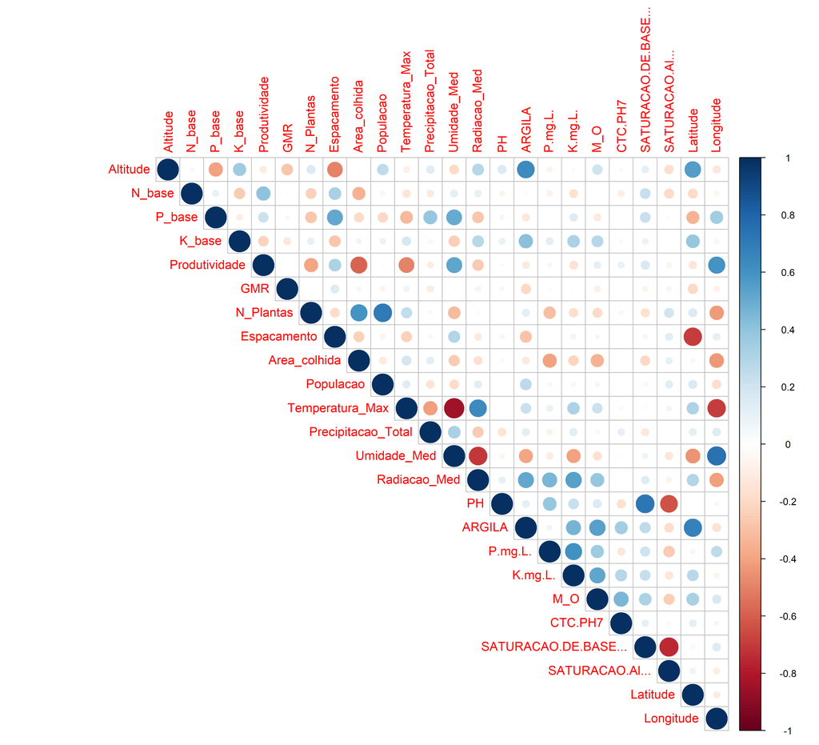

O gráfico de correlação entre as variáveis pode ser interpretado a partir do tamanho dos círculos e da cor. Quanto maior o círculo e mais escura é a cor mais forte é a correlação, também, se puxar mais para o azul é positiva, se for vermelha é negativa.

Principais medidas da variável de interesse e um gráfico para mostrar frequência de produtividade

**Média da produtividade:** 2458

**Desvio padrão da produtividade:** 1434

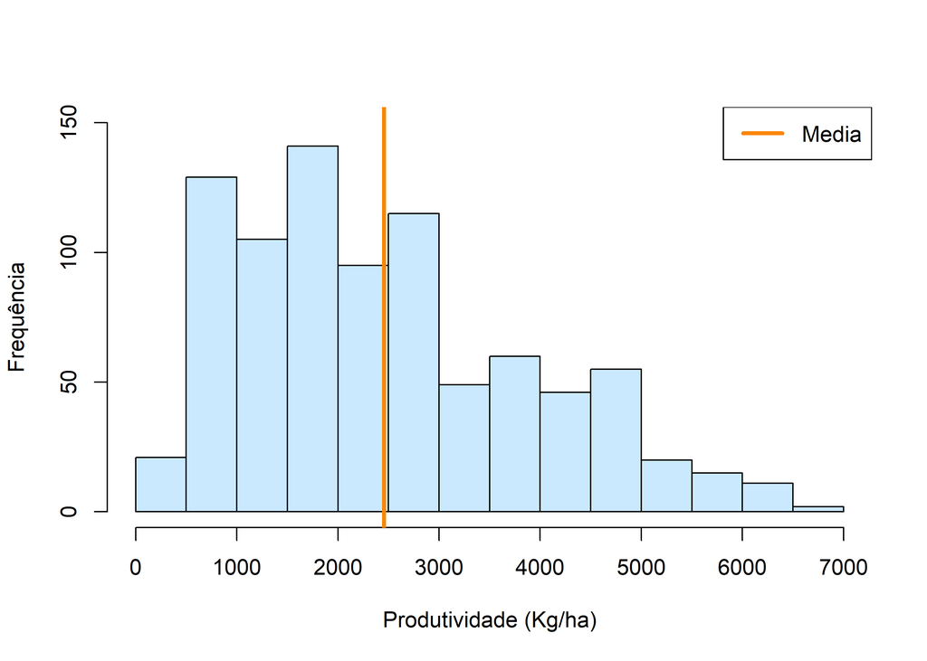

O gráfico de boxplot mostra a relação entre os anos das safras com a produtividade

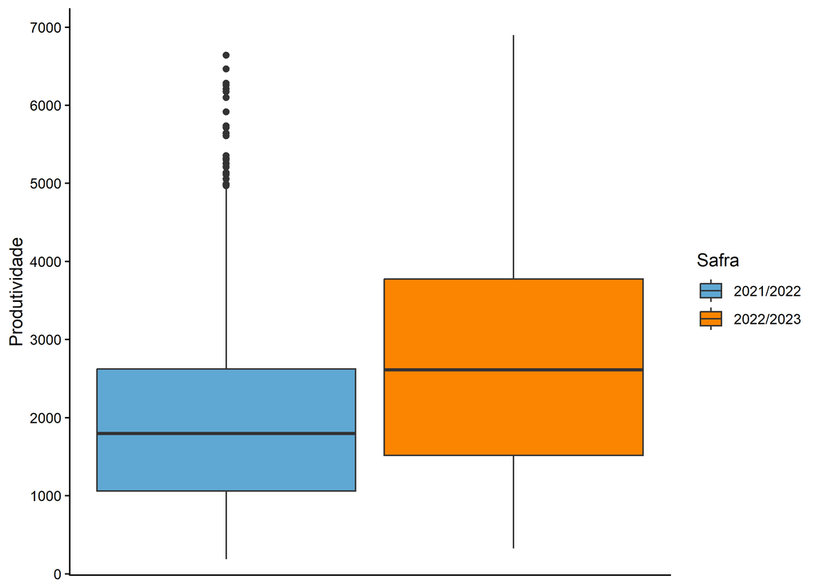

Nota-se um diferença de produtividade entre as duas safras, de certa forma a variável `Safra` deveria ser significativa para a explicação da produtividade de soja, no entanto ja tem relação com outras variáveis do modelo. Além disso, deve explicar a alta variabilidade dos erros, conforme será apresentado nas suposições do modelo.

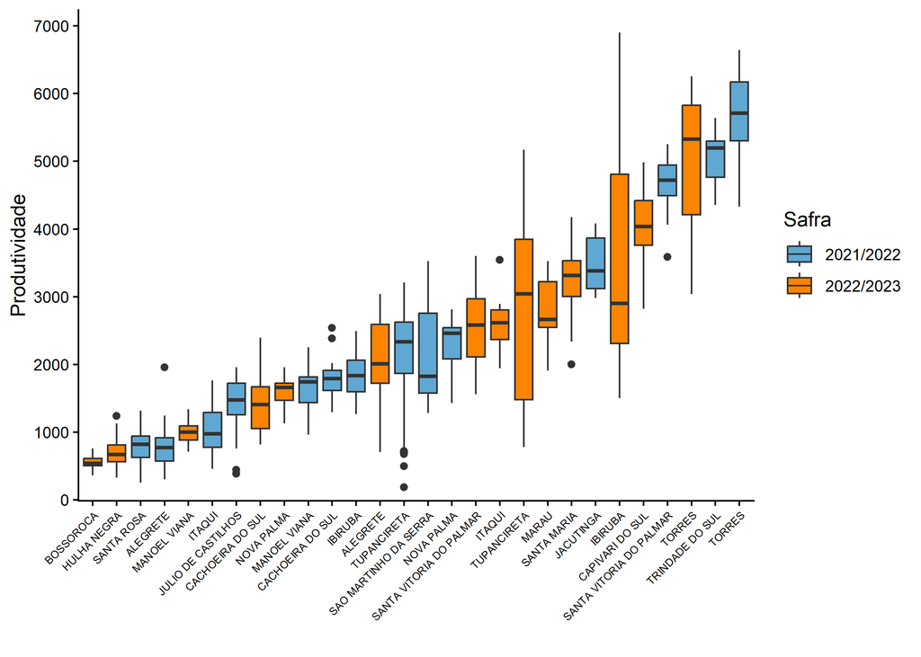

A partir do gráfico percebe-se a alta variabilidade de produtividade entre os locais de ensaio nas duas safras.

# Ajustes dos Dados

1 - Inicialmente foi removida uma cultivar experimental e cultivares com grupos de maturação relativos maiores que 7

2 - Os locais Santa Rosa e Jacutinga apresentaram ser pontos influêntes para o modelo. Logo para o ajuste foi melhor remover essas observações

3 - Locais os quais não tiveram uma cultura antes do plantio de soja ou tiveram mix também foram pontos de alavancagem para o modelo.

4 - Criação da variável `mês`, relacionada a data de plantio, ou seja, invés de ter dia e mês, tem se apenas o mês

5 - Foi alterado a variável `Terras`, em que Baixas recebe 0 e Altas recebe 1. A variável `Ambiente`, “irrigado” = 1 e “sequeiro” = 0

Os dados depois de filtrados e selecionados as variáveis importantes para o modelo, é dado por:

|  | Terras | Ambiente | Cultura_Ant | P_base | N_base | Produtividade | GMR | Espacamento | Temperatura_Max | PH | M_O | mes |
| --- | --- | --- | --- | --- | --- | --- | --- | --- | --- | --- | --- | --- |
| 308 | 0 | 1 | azevem | 135.0 | 9.0 | 4330.1250 | 6.1 | 0.50 | 23.26305 | 4.9 | 2.0 | nov |
| 183 | 1 | 0 | aveia | 69.0 | 6.0 | 2585.2788 | 5.8 | 0.45 | 24.59763 | 5.0 | 2.6 | nov |
| 591 | 1 | 1 | aveia | 43.0 | 17.2 | 4275.1000 | 5.4 | 0.45 | 24.76108 | 4.9 | 3.0 | out |
| 12 | 0 | 0 | azevem | 69.0 | 13.5 | 405.2235 | 5.7 | 0.45 | 25.07801 | 4.8 | 1.2 | nov |
| 631 | 1 | 1 | trigo | 40.0 | 16.0 | 3592.3250 | 5.8 | 0.45 | 25.35516 | 5.1 | 2.9 | nov |
| 682 | 1 | 0 | trigo | 40.0 | 16.0 | 906.2000 | 5.4 | 0.45 | 25.35516 | 5.1 | 2.9 | nov |
| 231 | 1 | 1 | aveia e ervilhaca | 57.5 | 5.0 | 2897.3250 | 6.4 | 0.45 | 24.47887 | 6.3 | 2.8 | out |
| 254 | 1 | 1 | aveia e ervilhaca | 57.5 | 5.0 | 2735.3250 | 5.9 | 0.45 | 24.47887 | 6.3 | 2.8 | out |
| 257 | 1 | 1 | aveia e ervilhaca | 57.5 | 5.0 | 1058.9250 | 4.9 | 0.45 | 23.69126 | 4.8 | 2.7 | nov |
| 390 | 0 | 0 | azevem | 56.0 | 6.0 | 3135.2500 | 5.2 | 0.45 | 23.68543 | 5.3 | 2.0 | dez |